# Part II - Factors that Influences the ProsperLoans' LoanOriginalAmount

## by John Ametepe Agboku

## Investigation Overview

> Investigating the ProsperLoan dataset, i wanted to look at the factors that influences or determines the ProsperLoan LoanOriginalAmount. The main focus was on the BorrowerRate and the MonthlyLoanPayment.

> This led into including Term of the Loan, ProsperRating (Alpha), ProsperScore, IsBorrowerHomeowner, and IncomeRange into our main focus.

## Dataset Overview

> The data contains 113,937 loan data with 81 features. 14 features were selected and investigated but only 8 features were thoroughly investigated. The loans data before July 2009 were removed because the features selected because some of the selected features do not have those data and to make the analysis unbiased they were removed. The 14 features selected and investigated are:
> 1. LoanOriginationDate
> 2. Term
> 3. BorrowerRate
> 4. LoanOriginalAmount
> 5. IncomeRange
> 6. CurrentDelinquencies
> 7. DelinquenciesLast7years
> 8. ProsperRating (Alpha)
> 9. Occupation
> 10. EmploymentStatus
> 11. IsBorrowerHomeowner
> 12. MonthlyLoanPayment
> 13. LoanStatus
> 14. ProsperScore

Which was later trimmed down to these 8 features

1. Term
2. BorrowerRate
3. LoanOriginalAmount
4. IncomeRange
5. ProsperRating (Alpha)
6. IsBorrowerHomeowner
7. MonthlyLoanPayment
8. ProsperScore

## Data Wrangling

```
<class 'pandas.core.frame.DataFrame'>
Int64Index: 84853 entries, 1 to 113936
Data columns (total 14 columns):
 #   Column                   Non-Null Count  Dtype
---  ------                   --------------  -----
 0   IsBorrowerHomeowner      84853 non-null  bool
 1   Term                     84853 non-null  category
 2   BorrowerRate             84853 non-null  float64
 3   LoanOriginationDate      84853 non-null  datetime64[ns]
 4   IncomeRange              84853 non-null  category
 5   CurrentDelinquencies     84853 non-null  float64
 6   DelinquenciesLast7Years  84853 non-null  float64
 7   ProsperRating (Alpha)    84853 non-null  category
 8   Occupation               83520 non-null  object
 9   EmploymentStatus         84853 non-null  object
 10  MonthlyLoanPayment       84853 non-null  float64
 11  LoanStatus               84853 non-null  object
 12  ProsperScore             84853 non-null  category
 13  LoanOriginalAmount       84853 non-null  int64
dtypes: bool(1), category(4), datetime64[ns](1), float64(4), int64(1), object(3)
memory usage: 6.9+ MB
```

|  | BorrowerRate | CurrentDelinquencies | DelinquenciesLast7Years | MonthlyLoanPayment | LoanOriginalAmount |
| --- | --- | --- | --- | --- | --- |
| count | 84853.000000 | 84853.000000 | 84853.000000 | 84853.000000 | 84853.000000 |
| mean | 0.196022 | 0.322452 | 3.659435 | 291.930720 | 9083.440515 |
| std | 0.074631 | 1.111996 | 9.347957 | 186.678314 | 6287.860058 |
| min | 0.040000 | 0.000000 | 0.000000 | 0.000000 | 1000.000000 |
| 25% | 0.135900 | 0.000000 | 0.000000 | 157.330000 | 4000.000000 |
| 50% | 0.187500 | 0.000000 | 0.000000 | 251.940000 | 7500.000000 |
| 75% | 0.257400 | 0.000000 | 2.000000 | 388.350000 | 13500.000000 |
| max | 0.360000 | 51.000000 | 99.000000 | 2251.510000 | 35000.000000 |

## Distribution of LoanOriginalAmount

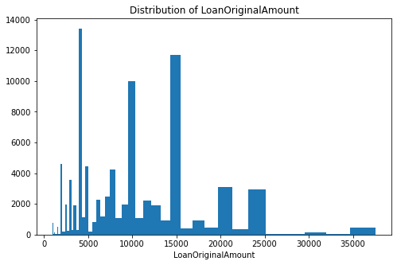

## Timeseries chart of LoanOriginalAmount

The timeseries graph shows that the LoanOriginalAmount per month increased steadily until the latter months of 2012 where there was a fall which was followed by an increased spike throughout 2013 but fell sharply in the early months of 2014

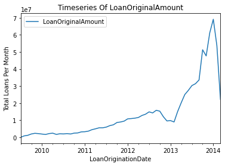

## The Relationship between LoanOriginalAmount, MonthlyPayment and BorrowerRate

The MonthlyLoanPayment increases as the LoanOriginalAmount also increases, and it can be seen that the low BorrowerRates are concentrated on the upper left side which shows Loans with smaller MonthlyLoanPayment. As the LoanOriginalAmount gets larger, the BorrowerRate can be seen becoming dimmer, i.e. smaller but with the MonthlyPayment increasing.Which means, loans with larger amount have higher MonthlyLoanPayment with smaller BorrowerRate as compared to loans with moderate to small LoanOriginalAmount that has smaller MonthlyLoanPayment but larger BorrowerRate But as the MonthlyLoanPayment increases, the BorrowerRate decreases.

In summary, As the LoanOriginalAmount increases, the MonthlyLoanPayment alos increases but the BorrowerRate decreases

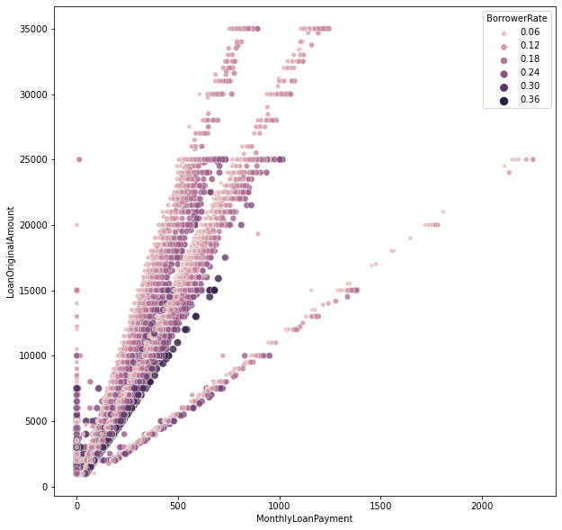

## The Relationship between LoanOriginalAmount, BorrowerRate and Term i.e. (Term of the Loan)

The relationship between these variables shows that for loans with 36-month term are either huge LoanOriginalAmount with lower rates or small with higher rates. And Loans with 60-month Term are concentrated on the upper right of the chart. Showing Loans with rates above 0.1 and LoanOriginalAmount approximately 7000 have longer have 60-month term.

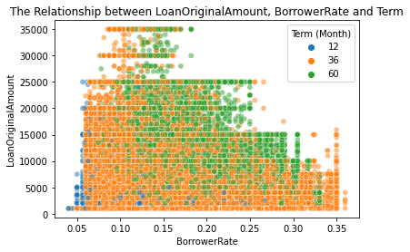

The loans with the best ProsperRating (Alpha) have lower BorrowerRate and the loans with the worst rating have high BorrowerRate

[figure not shown]

Just like the ProsperRating(Alpha), the lower BorrowerRate the better (Higher) the ProsperScore.

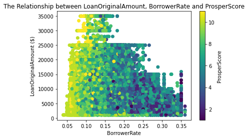

The loan with longer Term rises faster the loans with short terms. From this it can be concluded that, the loans with longer Terms have smaller MonthlyLoanPayment as compared to loans with shorter term.

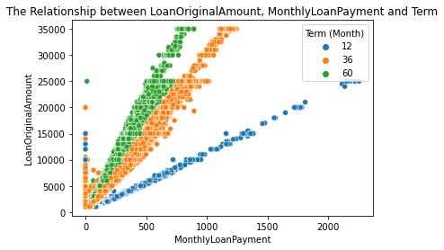

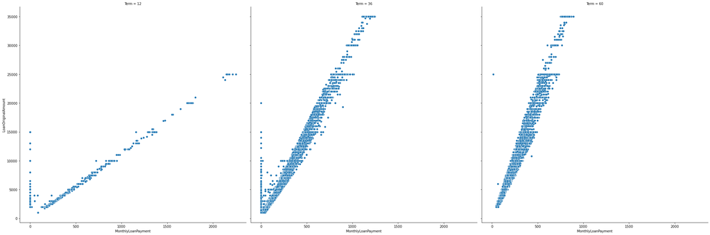